# 5 - Multi-Sample Multi-Condition Differential Expression

Author

CDN team

Published

March 18, 2024

## Introduction

Another way to process single-cell data is to pseudobulk the samples by aggregating the gene counts for cells belonging to each cell type by sample. This results in a single count value per gene per cell type per sample which is similar to a bulk matrix. Single-cell sparse matrices contain a lot of zeros which create a complicated distribution that makes it less sensitive to recognizing lowly expressed genes. Pseudobulking single-cell data allows us to benefit from the statistical rigor of existing bulk DE analysis.

### Useful Resources

- [Bioconductor DESeq2 workflow](https://www.bioconductor.org/packages/devel/bioc/vignettes/DESeq2/inst/doc/DESeq2.html#interactions) ⭐️
- [Bioinformagician DESeq2 workflow](https://www.youtube.com/watch?v=04gB2owLKus)
- [Bioinformagician DESeq2 walk-through](https://www.youtube.com/watch?v=0b24mpzM_5M&t=1204s)
- [Confronting false disocveries in single-cell differential expression](https://www.nature.com/articles/s41467-021-25960-2)

### Key Takeaways

1. Aggregating gene counts at the sample level provides another way to determine differentially expressed genes in single-cell data.
2. Pseudobulking single-cell data allows scientists to benefit from the statistical rigor of pre-existing bulk DE analysis on their single-cell data.
3. Having a minimum of 3 replicates per condition is necessary to be able to obtain statistically significant results.

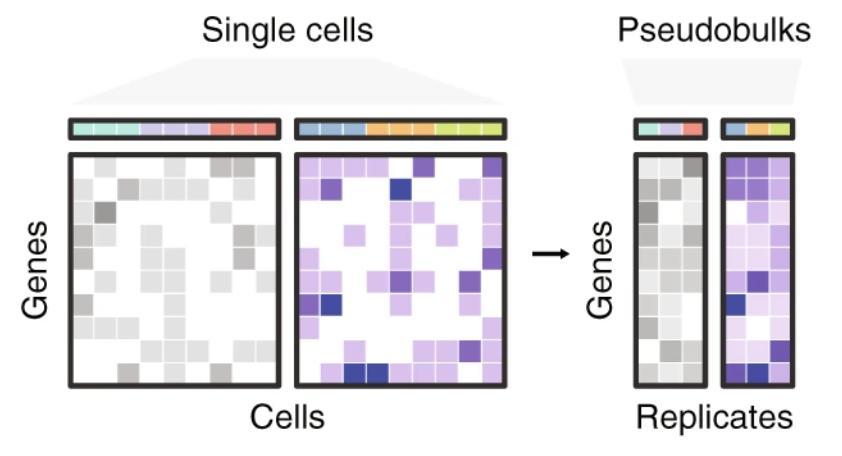

*Squair, J.W., Gautier, M., Kathe, C. et al. Confronting false discoveries in single-cell differential expression. Nat Commun 12, 5692 (2021). https://doi.org/10.1038/s41467-021-25960-2*

## Process Overview

1. Load R object
2. Aggregate gene counts via AggregateExpression()
3. Set up DESeq()-friendly matrix format
4. Run DESeq()’s statistical tests
5. Visualize results!

## Libraries

### Installation

```r
if (!requireNamespace("tidyverse", quietly = TRUE))
    install.packages('tidyverse')
if (!requireNamespace("Seurat", quietly = TRUE))
    install.packages('Seurat')
if (!requireNamespace("colorBlindness", quietly = TRUE))
    install.packages('colorBlindness')
if (!requireNamespace("RColorBrewer", quietly = TRUE))
    install.packages('RColorBrewer')
# Presto speeds up Wilcoxon tests for marker gene calculation in Seurat
if (!requireNamespace("presto", quietly = TRUE))
    devtools::install_github('immunogenomics/presto')
if (!requireNamespace("DESeq2", quietly = TRUE))
    BiocManager::install('DESeq2')
if (!requireNamespace("org.Hs.eg.db", quietly = TRUE))
    BiocManager::install('org.Hs.eg.db')
if (!requireNamespace("Matrix", quietly = TRUE))
    install.packages('Matrix')
if (!requireNamespace("tictoc", quietly = TRUE))
    install.packages('tictoc')
if (!requireNamespace("AnnotationDbi", quietly = TRUE))
    install.packages('AnnotationDbi')
if (!requireNamespace("DT", quietly = TRUE))
    install.packages('DT')
if (!requireNamespace("EnhancedVolcano", quietly = TRUE))
    BiocManager::install('EnhancedVolcano')
if (!requireNamespace("sparseMatrixStats", quietly = TRUE))
    BiocManager::install('sparseMatrixStats')
if (!requireNamespace("openxlsx", quietly = TRUE))
    install.packages('openxlsx')
```

### Load Libraries

```r
suppressPackageStartupMessages({
  library(presto)
  library(DESeq2)
  library(tidyverse)
  library(Seurat)
  library(colorBlindness)
  library(RColorBrewer)
  library(org.Hs.eg.db)
  library(Matrix)
  library(tictoc)
  library(AnnotationDbi)
  library(DT)
  library(EnhancedVolcano)
  library(sparseMatrixStats)
  library(openxlsx)
  })

# Set seed to your favorite number for reproducibility
set.seed(21)
```

## Set working directory

Uncomment commands below to see what directory you are currently working in and set the correct one

```r
# getwd()
# setwd('./workshops/navigating-the-single-cell-landscape-a-comprehensive-workshop-on-scrnaseq/day-1/')
```

## Load Data

### Load Seurat object

```r
# 'se' or 'srobj' are common abbreviations for Seurat objects
srobj <- readRDS('../data/d8e35450-de43-451a-9979-276eac688bce.rds')

# 'genes' is a gene conversion table to convert ENSG to readable gene symbols
genes <- read_csv('../data/cov_flu_gene_names_table.csv')
```

Since we are modifying the names of the genes we need to recreate the Seurat object. In this process we need to ensure that mtx or contains the raw counts (integers) and not the normalized data.

```r
# Ensure that mtx or your desired data is in integer format.
mtx <- srobj@assays$RNA@data
# NOTE: Run command below to ensure data is class 'numeric'
# class(mtx@x)
mtx[1:10,1:10] # Don't put normalized data into DESeq
```

```
10 x 10 sparse Matrix of class "dgCMatrix"

ENSG00000000003 . . . . . . . . . .
ENSG00000000005 . . . . . . . . . .
ENSG00000000419 . . . . . . . 1 . 1
ENSG00000000457 . . . . . . . . . .
ENSG00000000460 . . . . . 1 . . . .
ENSG00000000938 . . 1 2 . . 3 . 1 1
ENSG00000000971 . . . . . . . . . .
ENSG00000001036 . . . . . . 1 . . .
ENSG00000001084 . . . . 3 . 2 . . 1
ENSG00000001167 . . . . . . . . . .
```

```r
# Set rownames to be gene names
rownames(mtx) <- genes[match(row.names(mtx), genes$index), ]$feature_name

# Remake Seurat object
se <- CreateSeuratObject(counts = mtx, meta.data = srobj@meta.data)
se
```

```
An object of class Seurat
33234 features across 59572 samples within 1 assay
Active assay: RNA (33234 features, 0 variable features)
 1 layer present: counts
```

Set color palette

```r
pal <- paletteMartin
names(pal) <- sort(unique(se$Celltype))
```

## Analysis

### Seurat pre-processing

```r
se <- se %>%
    NormalizeData(verbose = FALSE) %>%
    FindVariableFeatures(
        method = "vst",
        nfeatures = 3000,
        verbose = FALSE) %>%
    ScaleData(verbose = FALSE) %>%
    RunPCA(verbose = FALSE) %>%
    RunUMAP(dims = 1:30, verbose = FALSE, n.components=3L)
```

Visualize PCs

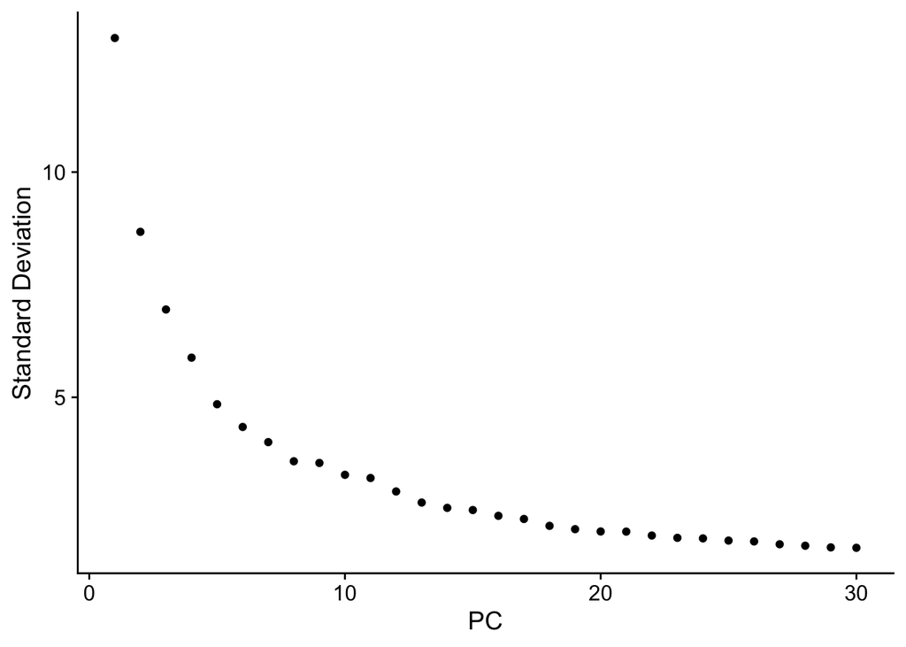

```r
# Elbow plot of PCs
# NOTE: First 15-20 PCs hold most of the information
ElbowPlot(se, ndims = 30)
```

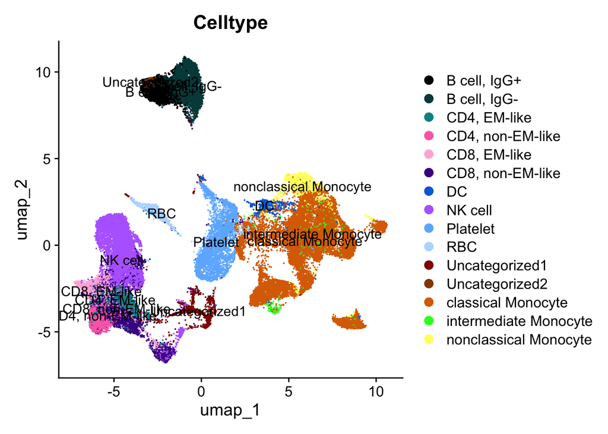

```r
# Group cells by annotation
DimPlot(
    se,
    group.by = c("Celltype"),
    label = TRUE,
    cols = pal)
```

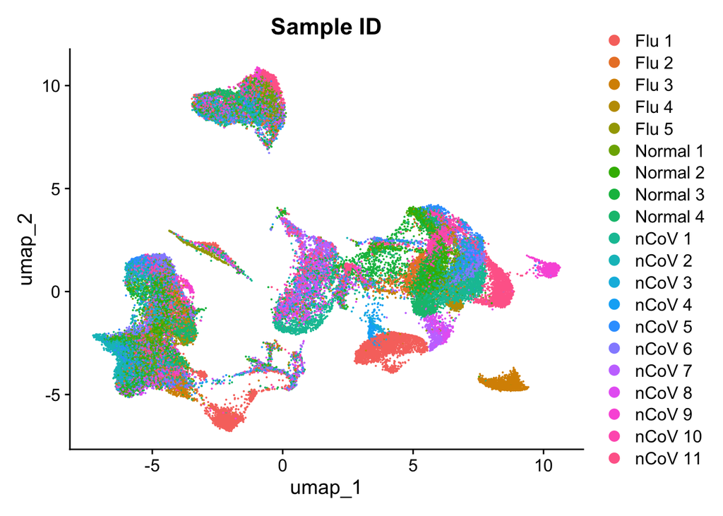

```r
# Group cells by sample
DimPlot(
  se,
  group.by = c('Sample ID')
  )
```

Because DESeq() is outside of Seurat, let’s modify strings with special characters to avoid complications later.

```r
se@meta.data <- se@meta.data %>%
  mutate(
    Celltype = str_replace(Celltype, ", ", "_"),
    Celltype = str_replace(Celltype, "G\\-", "Gneg"),
    Celltype = str_replace(Celltype, "G\\+", "Gpos")
  )
```

Check to make sure strings were modified correctly before next steps

```r
unique(se@meta.data$Celltype)
```

```
 [1] "NK cell"               "CD4_EM-like"           "CD8_non-EM-like"       "classical Monocyte"    "B cell_IgGpos"         "DC"                    "CD8_EM-like"           "B cell_IgGneg"         "intermediate Monocyte" "CD4_non-EM-like"       "Platelet"              "nonclassical Monocyte" "Uncate…
```

### Aggregate Expression

The AggregateExpression() function arranges the cell by gene matrix to group gene counts by the Sample ID and labelled Celltype of each cell. It outputs either a sparse matrix or a new `Seurat` object if `return.Seurat = TRUE`. **Aggregation is the pseudobulking step where genes are summed across cells per celltype per sample.**

```r
# Here we separate the dataset into two subsets
# CD8 and CD4 T cells
Idents(se) <- se@meta.data$Celltype
cd4sr <- subset(se, idents = c('CD4_EM-like', 'CD4_non-EM-like'))

# Filter for genes with 0 counts
cd4sr <- cd4sr[sparseMatrixStats::rowSums2(cd4sr@assays$RNA$data) > 0, ]

# 1- Sum gene counts and group by Sample ID
cd4_pseudobulk <- AggregateExpression(cd4sr, group.by = 'Sample ID')$RNA
dim(cd4_pseudobulk)
```

```
[1] 20245    20
```

## Run DESeq

### Explanation

DESeq takes 3 main parameters.

1. countData = A subset of the aggregated counts. Counts have to be whole numbers.
2. colData = Sample metadata.
3. design = Tells the DESeq function what comparisons to make.

Prepare data to create a DESeq object.

```r
# Here we run DESeq2, the classic differential expression package.

# 2 - Subset the sample metadata to align with the sample x gene matrix.
sample_info <- strsplit(colnames(cd4_pseudobulk), " ")

lvls <- c("Normal", "Flu", "nCoV")
colData <- data.frame(
  sample = colnames(cd4_pseudobulk),
  condition = factor(sapply(sample_info, `[`, 1), levels = lvls)
)
DT::datatable(colData)
```

|  | sample | condition |
| --- | --- | --- |
| 1 | Flu 1 | Flu |
| 2 | Flu 2 | Flu |
| 3 | Flu 3 | Flu |
| 4 | Flu 4 | Flu |
| 5 | Flu 5 | Flu |
| 6 | Normal 1 | Normal |
| 7 | Normal 2 | Normal |
| 8 | Normal 3 | Normal |
| 9 | Normal 4 | Normal |
| 10 | nCoV 1 | nCoV |

[output cut: 10 more lines]

```r
rownames(colData) <- colnames(cd4_pseudobulk)

# Note: If you encounter an error here, make sure dplyr is installed/running.

# Set "sample" variable to join the dataframes on
se@meta.data <- se@meta.data %>%
  dplyr::rename("sample" = "Sample ID")

# Join the metadata in se@meta.data to colData dataframe
colData <- colData %>%
  left_join(se@meta.data %>%
              dplyr::select('sample', 'Disease group') %>%
              distinct()
)
```

Create DESeq object

```r
# Create the DESeq object, where tests can be run.
## Check out the documentation online for more.
dds <- DESeqDataSetFromMatrix(countData = cd4_pseudobulk,
                                colData = colData,
                                design = ~ condition)
# this runs the test
dds <- DESeq(dds)
dds
```

```
class: DESeqDataSet
dim: 20245 20
metadata(1): version
assays(6): counts mu ... replaceCounts replaceCooks
rownames(20245): TSPAN6 DPM1 ... RP5-1067M6.6 RP1-111C20.3
rowData names(27): baseMean baseVar ... maxCooks replace
colnames(20): Flu 1 Flu 2 ... nCoV 10 nCoV 11
colData names(5): sample condition Disease group sizeFactor replaceable
```

## Results

### What does this mean?

Results function examples:

- res <- results(dds)
- res <- results(dds, contrast = c(“metadata_var”, “opt1”, “opt2”))
- res <- results(dds, name = “defined_condition”)

Results output guide:

- Positive log2fold change are up-regulated
- Negative are down-regulated
- Can set the p-value to a certain threshold

```r
results(dds, contrast = c("condition", "Flu", "Normal"))
```

```
log2 fold change (MLE): condition Flu vs Normal
Wald test p-value: condition Flu vs Normal
DataFrame with 20245 rows and 6 columns
               baseMean log2FoldChange     lfcSE      stat      pvalue      padj
              <numeric>      <numeric> <numeric> <numeric>   <numeric> <numeric>
TSPAN6         0.645556       0.244233  1.508633   0.16189 0.871392175        NA
DPM1          27.463577      -0.826744  0.292899  -2.82262 0.004763231 0.1119098
SCYL3          7.185494      -0.585661  0.486577  -1.20363 0.228731049 0.5717263
C1orf112       2.273756       1.169670  0.789268   1.48197 0.138348622        NA
FGR            5.675184       2.401179  0.634246   3.78588 0.000153168 0.0175232
...                 ...            ...       ...       ...         ...       ...
RP11-63A11.2  0.0103290        2.38127   4.53175  0.525465    0.599260        NA
RP11-397E7.6  1.4276709        1.05233   2.17004  0.484936    0.627721        NA
RP11-826N14.7 1.6676234       -1.05587   1.15535 -0.913897    0.360771        NA
RP5-1067M6.6  0.0175983        0.00000   4.53175  0.000000    1.000000        NA
RP1-111C20.3  0.0311251        0.00000   4.53175  0.000000    1.000000        NA
```

Extract results from the DESeq object

```r
# run 'resultsNames(dds)' to see "name" options
# current options: "condition_Flu_vs_Normal"  "condition_nCoV_vs_Normal"
# this pulls results from the DESeq object
res <- results(dds, name = "condition_Flu_vs_Normal")
res
```

```
log2 fold change (MLE): condition Flu vs Normal
Wald test p-value: condition Flu vs Normal
DataFrame with 20245 rows and 6 columns
               baseMean log2FoldChange     lfcSE      stat      pvalue      padj
              <numeric>      <numeric> <numeric> <numeric>   <numeric> <numeric>
TSPAN6         0.645556       0.244233  1.508633   0.16189 0.871392175        NA
DPM1          27.463577      -0.826744  0.292899  -2.82262 0.004763231 0.1119098
SCYL3          7.185494      -0.585661  0.486577  -1.20363 0.228731049 0.5717263
C1orf112       2.273756       1.169670  0.789268   1.48197 0.138348622        NA
FGR            5.675184       2.401179  0.634246   3.78588 0.000153168 0.0175232
...                 ...            ...       ...       ...         ...       ...
RP11-63A11.2  0.0103290        2.38127   4.53175  0.525465    0.599260        NA
RP11-397E7.6  1.4276709        1.05233   2.17004  0.484936    0.627721        NA
RP11-826N14.7 1.6676234       -1.05587   1.15535 -0.913897    0.360771        NA
RP5-1067M6.6  0.0175983        3.10259   4.53175  0.684633    0.493576        NA
RP1-111C20.3  0.0311251        3.10258   4.53175  0.684632    0.493576        NA
```

```r
# Summary function
summary(res)
```

```
out of 20245 with nonzero total read count
adjusted p-value < 0.1
LFC > 0 (up)       : 251, 1.2%
LFC < 0 (down)     : 75, 0.37%
outliers [1]       : 16, 0.079%
low counts [2]     : 11763, 58%
(mean count < 5)
[1] see 'cooksCutoff' argument of ?results
[2] see 'independentFiltering' argument of ?results
```

Save Results  
**NOTE: Save all data so if a collaborator asks what the comparison was, you have the header stored or rerun analysis.**

```r
# Save intermediate files
dir.create('pseudobulk_analysis')
dir.create('pseudobulk_analysis/data')
```

```r
# Comment out once created
dir.create('pseudobulk_analysis/results')

# Save as a R object
saveRDS(object = res,
        file = 'pseudobulk_analysis/results/cd4_annot_pseudobulk_results.rds')

# Filtering and rearranging for plotting
restbl <- res %>%
  data.frame %>%
  rownames_to_column('gene')

# Write data frame results to CSV
write.csv(
  restbl,
  file='pseudobulk_analysis/results/cd4_annot_pseudobulk_results.csv'
  )
```

## Visualize Results

Volcano plot is one of the most utilized ways to visualize the results of differential expression analyses.

### From CSV object

```r
res <- read_csv('pseudobulk_analysis/results/cd4_annot_pseudobulk_results.csv')
```

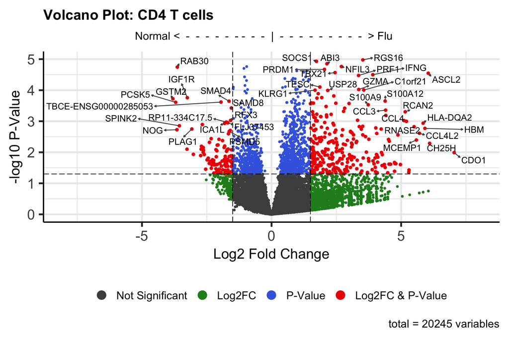

```r
library(EnhancedVolcano)
EnhancedVolcano(res,
                lab = res$gene,
                x = 'log2FoldChange',
                y = 'pvalue',
                xlim = c(-8, 8),
                ylim = c(0, 5),
                title = 'Volcano Plot: CD4 T cells',
                subtitle = ' Normal <  -  -  -  -  -  - -  -  -  |  -  -  -  -  -  -  -  -  -  > Flu      ',
                xlab = 'Log2 Fold Change',
                ylab = '-log10 P-Value',
                pCutoff = 0.05,
                FCcutoff = 1.5,
                pointSize = c(ifelse(res$pvalue < 0.05 & abs(res$log2FoldChange) > 1.5, 1.5, 1)),
                labSize = 4.0,
                col = c('grey30', 'forestgreen', 'royalblue', 'red2'),
                colAlpha = 1,
                legendLabels=c('Not Significant', 'Log2FC', 'P-Value', 'Log2FC & P-Value'),
                legendPosition = 'right',
                legendLabSize = 14,
                drawConnectors = TRUE,
                widthConnectors = 0.5,
                colConnectors = 'grey30') +
  theme(
    plot.subtitle = element_text(hjust = 0.5),
    legend.position = 'bottom'
  )
```

NOTE: There are many genes turned on in the infected group

We use the raw p-value (pval) because the adjusted p-value (padj) loses some information when FDR-corrected. # https://support.bioconductor.org/p/62384/ # https://support.bioconductor.org/p/98442/ # https://www.biostars.org/p/190779/

### From RDS object

```r
res <- readRDS('pseudobulk_analysis/results/cd4_annot_pseudobulk_results.rds')
res
```

```
log2 fold change (MLE): condition Flu vs Normal
Wald test p-value: condition Flu vs Normal
DataFrame with 20245 rows and 6 columns
               baseMean log2FoldChange     lfcSE      stat      pvalue      padj
              <numeric>      <numeric> <numeric> <numeric>   <numeric> <numeric>
TSPAN6         0.645556       0.244233  1.508633   0.16189 0.871392175        NA
DPM1          27.463577      -0.826744  0.292899  -2.82262 0.004763231 0.1119098
SCYL3          7.185494      -0.585661  0.486577  -1.20363 0.228731049 0.5717263
C1orf112       2.273756       1.169670  0.789268   1.48197 0.138348622        NA
FGR            5.675184       2.401179  0.634246   3.78588 0.000153168 0.0175232
...                 ...            ...       ...       ...         ...       ...
RP11-63A11.2  0.0103290        2.38127   4.53175  0.525465    0.599260        NA
RP11-397E7.6  1.4276709        1.05233   2.17004  0.484936    0.627721        NA
RP11-826N14.7 1.6676234       -1.05587   1.15535 -0.913897    0.360771        NA
RP5-1067M6.6  0.0175983        3.10259   4.53175  0.684633    0.493576        NA
RP1-111C20.3  0.0311251        3.10258   4.53175  0.684632    0.493576        NA
```

Volcano plot is often the ultimate goal of differential expression analysis.

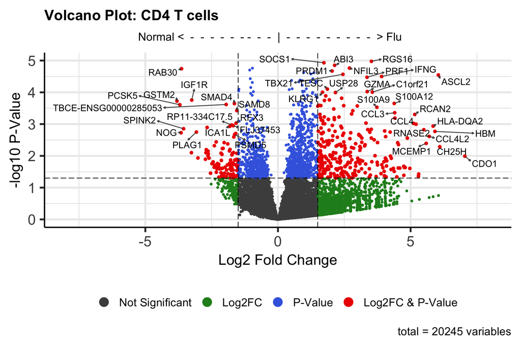

```r
library(EnhancedVolcano)
EnhancedVolcano(res,
                lab = rownames(res),
                x = 'log2FoldChange',
                y = 'pvalue',
                xlim = c(-8, 8),
                ylim = c(0, 5),
                title = 'Volcano Plot: CD4 T cells',
                subtitle = ' Normal <  -  -  -  -  -  - -  -  -  |  -  -  -  -  -  -  -  -  -  > Flu      ',
                xlab = 'Log2 Fold Change',
                ylab = '-log10 P-Value',
                pCutoff = 0.05,
                FCcutoff = 1.5,
                pointSize = c(ifelse(res$pvalue < 0.05 & abs(res$log2FoldChange) > 1.5, 1.5, 1)),
                labSize = 4.0,
                col = c('grey30', 'forestgreen', 'royalblue', 'red2'),
                colAlpha = 1,
                legendLabels=c('Not Significant', 'Log2FC', 'P-Value', 'Log2FC & P-Value'),
                legendPosition = 'right',
                legendLabSize = 14,
                drawConnectors = TRUE,
                widthConnectors = 0.5,
                colConnectors = 'grey30') +
  theme(
    plot.subtitle = element_text(hjust = 0.5),
    legend.position = 'bottom'
  )
```

## Automate this for pre-annotated cell types

### Aggregate gene counts for each sample

```r
# Let's create pseudobulk profiles for all cell type by sample combinations
annot_pseudobulk <- AggregateExpression(
  se, # object name
  group.by = c('sample','Celltype')
  )$RNA # desired assay
# NOTE: Can add "return.seurat = TRUE" and assign this to a new Seurat obj
```

### Prepare metadata

Prep the data to create DESeq object

```r
# We have to rearrange the data to get it into the DESeq object.
# colData is the sample-level metadata

sample_info <- strsplit(colnames(annot_pseudobulk), "_")

# Define level order in a factor to ensure the correct conditions are compared
# i.e. 'Normal' v 'Flu' and 'Normal' v 'nCoV'
# Default levels priority is based on alphabetical order
lvls <- c("Normal", "Flu", "nCoV")
ftr <- str_split(colnames(annot_pseudobulk), pattern = " ", simplify = TRUE)
```

```r
# 1 - Consolidate sample metadata
colData <- data.frame(
  sample = colnames(annot_pseudobulk), # i.e. 'Flu 1_B cell-IgGneg'
  condition = factor(ftr[, 1], levels = lvls), # i.e. 'Flu'
  donor_id = sapply(sample_info, `[`, 1), # i.e. 'Flu 1'
  celltype = sapply(sample_info, `[`, 2) # i.e. 'B cell-IgGneg'
)

# Ensure unique rownames in colData for DESeqDataSet
rownames(colData) <- colnames(annot_pseudobulk)

colData <- colData %>%
  left_join(se@meta.data %>%
  dplyr::select('sample', 'Disease group') %>%
              distinct()
  ) %>%
  column_to_rownames(var = 'sample')
```

### Run DESeq() and save results (.rds, .csv, .xlsx)

```r
# 2 - loop through Celltypes using lapply() - i.e. 'cluster' = "B cell-IgGneg"
all_ct_ls <- lapply(unique(colData$celltype), function(cluster) {
  # 3 - Initialize list of celltypes in aggregated matrix
  split <- str_split_fixed(colnames(annot_pseudobulk),pattern='_',n=2)[,2]
  # 4 - Subset the aggregated matrix ('annot_pseudobulk') by cluster
  bulk_subset <- annot_pseudobulk[,split %in% cluster ]
  # 5 - Filter the subset matrix for genes with more than 0 counts
  bulk_filter <- bulk_subset[sparseMatrixStats::rowSums2(bulk_subset) > 0, ]
  # 6 - Subset the celltype metadata
  data_subset <- colData %>% filter(celltype %in% cluster)
  # 7 - Initialize DESeq matrix
  dds <- DESeqDataSetFromMatrix(countData = bulk_filter,
                                colData = data_subset,
                                design = ~ condition)

  # 8 - Manipulate strings to turn all spaces and special char to underscores
  cluster <- stringr::str_replace(cluster, " ", "_")
  c <- stringr::str_replace(cluster, "\\-", "_")
  # 9 - Run DESeq()
  dds <- DESeq(dds)
  # resultsNames(dds) - Run to see list of tests

  # 10 - Calculate results
  res <- results(dds, name = "condition_Flu_vs_Normal")

  # 11 - Save R object, CSV file, and add CSV file to .xlsx
  saveRDS(
    res,
    glue::glue("pseudobulk_analysis/results/{c}_fluVnorm_annot_pseudobulk.rds"))

  restbl <- res %>% data.frame %>% rownames_to_column('gene')
  write_csv(
    restbl,
    glue::glue("pseudobulk_analysis/results/{c}_fluVnorm_annot_pseudobulk.csv"))
  restbl
})

# 12 - Save .xlsx file here
names(all_ct_ls) <- unique(colData$celltype)
openxlsx::write.xlsx(
  all_ct_ls,
  file = "pseudobulk_analysis/results/flu_vs_normal_celltype.xlsx")
```

### Visualize results and save plots (.pdf)

```r
res_ls <- list.files('pseudobulk_analysis/results/', pattern = "*.rds")
suppressMessages({
dir.create('pseudobulk_analysis/figures/')
tmp <- lapply(res_ls, function(file) {
    print(file)
    res_df <- readRDS(glue::glue('pseudobulk_analysis/results/{file}'))
    test <- strsplit(file,split='_fluVnorm')[[1]][1]
    pdf(glue::glue("pseudobulk_analysis/figures/{test}_volcano.pdf"),width=9,height=6)

    print(EnhancedVolcano(res_df,
                lab = rownames(res_df),
                x = 'log2FoldChange',
                y = 'pvalue',
                xlim = c(-8, 8),
                ylim = c(0, 5),
                title = glue::glue('Volcano Plot: {test}'),
                subtitle = ' Normal <  -  -  -  -  -  - -  -  -  |  -  -  -  -  -  -  -  -  -  > Flu      ',
                xlab = 'Log2 Fold Change',
                ylab = '-log10 P-Value',
                pCutoff = 0.05,
                FCcutoff = 1.5,
                pointSize = c(ifelse(res_df$pvalue < 0.05 & abs(res_df$log2FoldChange) > 1.5, 1.5, 1)),
                labSize = 4.0,
                col = c('grey30', 'forestgreen', 'royalblue', 'red2'),
                colAlpha = 1,
                legendLabels=c('Not Significant','Log2FC','P-Value','Log2FC & P-Value'),
                legendPosition = 'right',
                legendLabSize = 14,
                drawConnectors = TRUE,
                widthConnectors = 0.5,
                colConnectors = 'grey30'))
    dev.off()
})
    })
```

```
[1] "B_cell_IgGneg_fluVnorm_annot_pseudobulk.rds"
```

```
[1] "B_cell_IgGpos_fluVnorm_annot_pseudobulk.rds"
```

```
[1] "cd4_annot_pseudobulk_results.rds"
```

```
[1] "CD4_EM-like_fluVnorm_annot_pseudobulk.rds"
```

```
[1] "CD4_non-EM-like_fluVnorm_annot_pseudobulk.rds"
```

```
[1] "CD8_EM-like_fluVnorm_annot_pseudobulk.rds"
```

```
[1] "CD8_non-EM-like_fluVnorm_annot_pseudobulk.rds"
```

```
[1] "classical_Monocyte_fluVnorm_annot_pseudobulk.rds"
```

```
[1] "DC_fluVnorm_annot_pseudobulk.rds"
```

```
[1] "intermediate_Monocyte_fluVnorm_annot_pseudobulk.rds"
```

```
[1] "NK_cell_fluVnorm_annot_pseudobulk.rds"
```

```
[1] "nonclassical_Monocyte_fluVnorm_annot_pseudobulk.rds"
```

```
[1] "Platelet_fluVnorm_annot_pseudobulk.rds"
```

```
[1] "RBC_fluVnorm_annot_pseudobulk.rds"
```

```
[1] "Uncategorized1_fluVnorm_annot_pseudobulk.rds"
```

```
[1] "Uncategorized2_fluVnorm_annot_pseudobulk.rds"
```

```r
list.files('pseudobulk_analysis/figures/')
```

```
 [1] "B_cell_IgGneg_volcano.pdf"                    "B_cell_IgGpos_volcano.pdf"                    "cd4_annot_pseudobulk_results.rds_volcano.pdf" "CD4_EM-like_volcano.pdf"                      "CD4_non-EM-like_volcano.pdf"                  "CD8_EM-like_volcano.pdf"                      "CD8_non-EM-l…
```